# Assignment#6

20182477 김효재

2021 5 23

## Sentiment Analysis on Twitter Dataset

“Tweets.csv” 파일은 트위터에서 미국의 6개 항공사(American, Delta, SouthWest, United, US Airways, Virgin America)를 언급하는 tweet 14,640개에 대한 정보를 수집한 데이터셋으로, 본 과제에서는 다음 두 변수 를 활용한다. 변수 airline_sentiment는 각 tweet 텍스트가 항공사에 대한 긍정적인 내용인지, 부정적인 내용인지, 중립적인 내용인지에 따라 positive, negative, neutral로 분류한 결과를 나타낸다. 본 과제에서는 tweet 텍스트로부터 positive/negative/neutral 여부를 판별하기 위한 모델을 만들어본다.

#### #1. 모델 수립하기 전에 데이터의 특성을 분석한다. 시각화 도구를 적절히 활용하자.

```r
#필요한 패키지를 불러오자
library(ggplot2)
library(wordcloud)
library(tm)
library(RColorBrewer)
library(dplyr)
#사용할 데이터파일을 불러오자. 이때 문자열이 모두 factor로 변환되지 않도록 옵션을 추가로 설정해준다.
tweets <- read.csv("C:/Users/chk/Documents/Tweets_win.csv", stringsAsFactors = FALSE)

#데이터의 구조와 이름을 확인해보자. 이번 과제에서 사용할 변수는 airline_sentiment와 text 변수이다.
str(tweets)
```

```
## 'data.frame':    14640 obs. of  15 variables:
##  $ tweet_id                    : num  5.7e+17 5.7e+17 5.7e+17 5.7e+17 5.7e+17 ...
##  $ airline_sentiment           : chr  "neutral" "positive" "neutral" "negative" ...
##  $ airline_sentiment_confidence: num  1 0.349 0.684 1 1 ...
##  $ negativereason              : chr  "" "" "" "Bad Flight" ...
##  $ negativereason_confidence   : num  NA 0 NA 0.703 1 ...
##  $ airline                     : chr  "Virgin America" "Virgin America" "Virgin America" "Virgin America" ...
##  $ airline_sentiment_gold      : chr  "" "" "" "" ...
##  $ name                        : chr  "cairdin" "jnardino" "yvonnalynn" "jnardino" ...
##  $ negativereason_gold         : chr  "" "" "" "" ...
##  $ retweet_count               : int  0 0 0 0 0 0 0 0 0 0 ...
##  $ text                        : chr  "@VirginAmerica What @dhepburn said." "@VirginAmerica plus you've added commercials to the experience... tacky." "@VirginAmerica I didn't today... Must mean I need to take another trip!" "@VirginAmerica it's really aggressive to blast obnoxious \"entertainmen…
##  $ tweet_coord                 : chr  "" "" "" "" ...
##  $ tweet_created               : chr  "2015-02-24 11:35:52 -0800" "2015-02-24 11:15:59 -0800" "2015-02-24 11:15:48 -0800" "2015-02-24 11:15:36 -0800" ...
##  $ tweet_location              : chr  "" "" "Lets Play" "" ...
##  $ user_timezone               : chr  "Eastern Time (US & Canada)" "Pacific Time (US & Canada)" "Central Time (US & Canada)" "Pacific Time (US & Canada)" ...
```

```r
names(tweets)
```

```
##  [1] "tweet_id"                     "airline_sentiment"
##  [3] "airline_sentiment_confidence" "negativereason"
##  [5] "negativereason_confidence"    "airline"
##  [7] "airline_sentiment_gold"       "name"
##  [9] "negativereason_gold"          "retweet_count"
## [11] "text"                         "tweet_coord"
## [13] "tweet_created"                "tweet_location"
## [15] "user_timezone"
```

```r
#사용할 변수에 어떤 데이터가 있는지 확인해보면 아래와 같다.
tweets$airline_sentiment %>% head(10)
```

```
##  [1] "neutral"  "positive" "neutral"  "negative" "negative" "negative"
##  [7] "positive" "neutral"  "positive" "positive"
```

```r
tweets$text %>% head(5)
```

```
## [1] "@VirginAmerica What @dhepburn said."
## [2] "@VirginAmerica plus you've added commercials to the experience... tacky."
## [3] "@VirginAmerica I didn't today... Must mean I need to take another trip!"
## [4] "@VirginAmerica it's really aggressive to blast obnoxious \"entertainment\" in your guests' faces &amp; they have little recourse"
## [5] "@VirginAmerica and it's a really big bad thing about it"
```

```r
#dataframe을 생성한다. 이때 target변수는 factor로 변환해주자.
df<- data.frame(sentiment = factor(tweets$airline_sentiment), text = tweets$text)
str(df)
```

```
## 'data.frame':    14640 obs. of  2 variables:
##  $ sentiment: Factor w/ 3 levels "negative","neutral",..: 2 3 2 1 1 1 3 2 3 3 ...
##  $ text     : chr  "@VirginAmerica What @dhepburn said." "@VirginAmerica plus you've added commercials to the experience... tacky." "@VirginAmerica I didn't today... Must mean I need to take another trip!" "@VirginAmerica it's really aggressive to blast obnoxious \"entertainment\" in your guests'…
```

```r
#Visualization=======================================================

#group_by()를 사용할 경우 출력결과가 데이터프레임이 아닌 tibble 형태로 생성된다.
sentiment = tweets %>% group_by(airline_sentiment) %>% summarise(count = n())
```

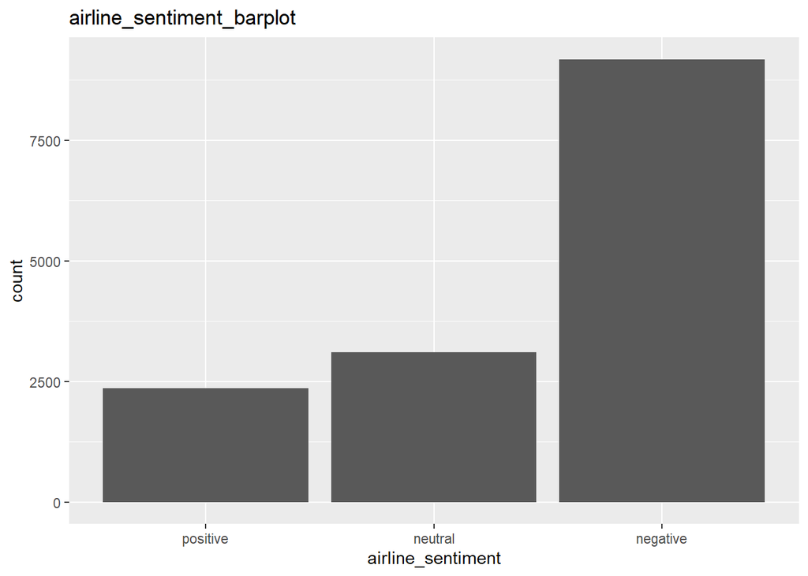

```r
sentiment <- sentiment[order(sentiment$airline_sentiment, decreasing=TRUE),]

#airline_sentiment의 분포를 확인해보자
ggplot(data=sentiment, aes(x=reorder(airline_sentiment,count), y= count)) + geom_bar(stat="identity")+ labs(x="airline_sentiment",title="airline_sentiment_barplot")
```

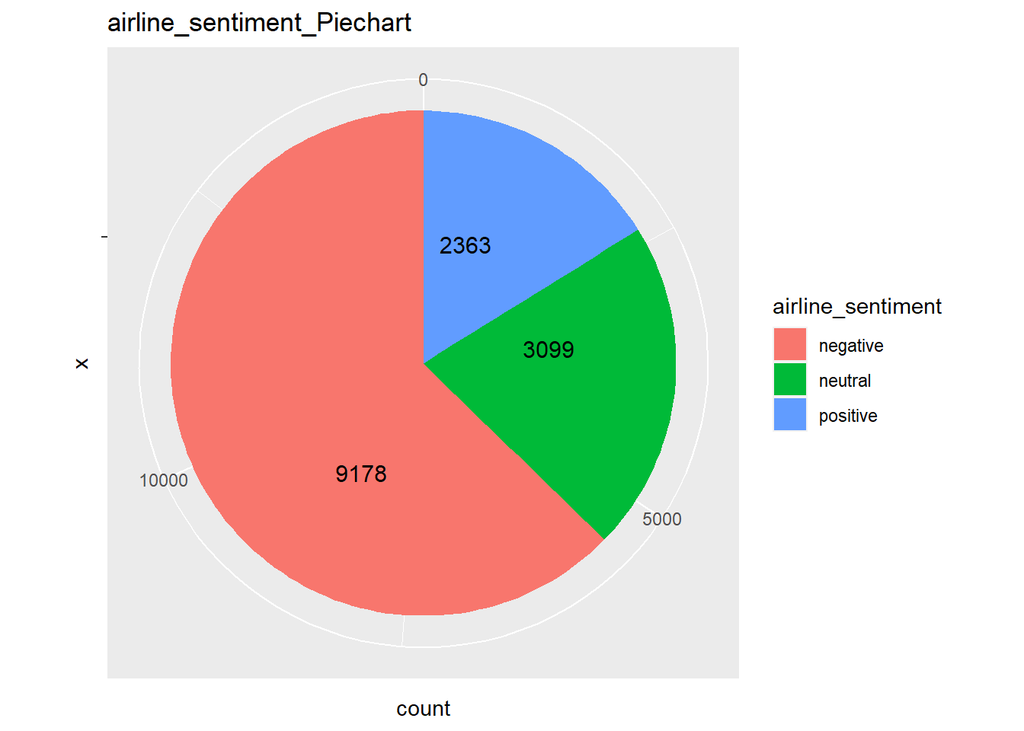

```r
ggplot(data=sentiment,aes(x="",y=count,fill=airline_sentiment))+geom_bar(width=1,stat="identity")+ geom_text(aes(y = count/3 + c(0, cumsum(count)[-length(count)]),
label=count), size=4)+coord_polar("y") + labs(title="airline_sentiment_Piechart")
```

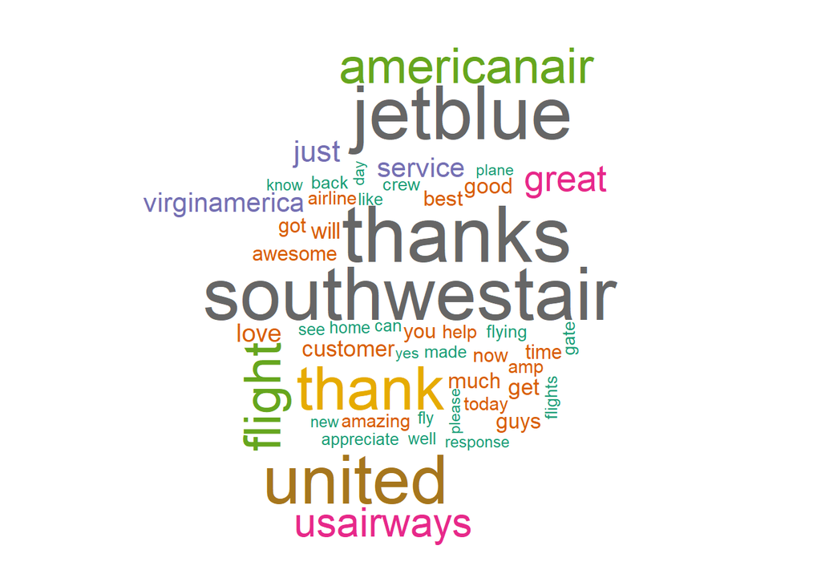

```r
#wordcloud를 활용해 시각화해보자
#메세지별로 분리해준다.
positive <- subset(df, sentiment=="positive")
neutral <- subset(df, sentiment=="neutral")
negative <- subset(df, sentiment=="negative")

#wordcloud를 생성한다. 최대 단어의 개수는 50개로 설정했다.
wordcloud(positive$text, max.words=50, colors=brewer.pal(8, "Dark2"))
```

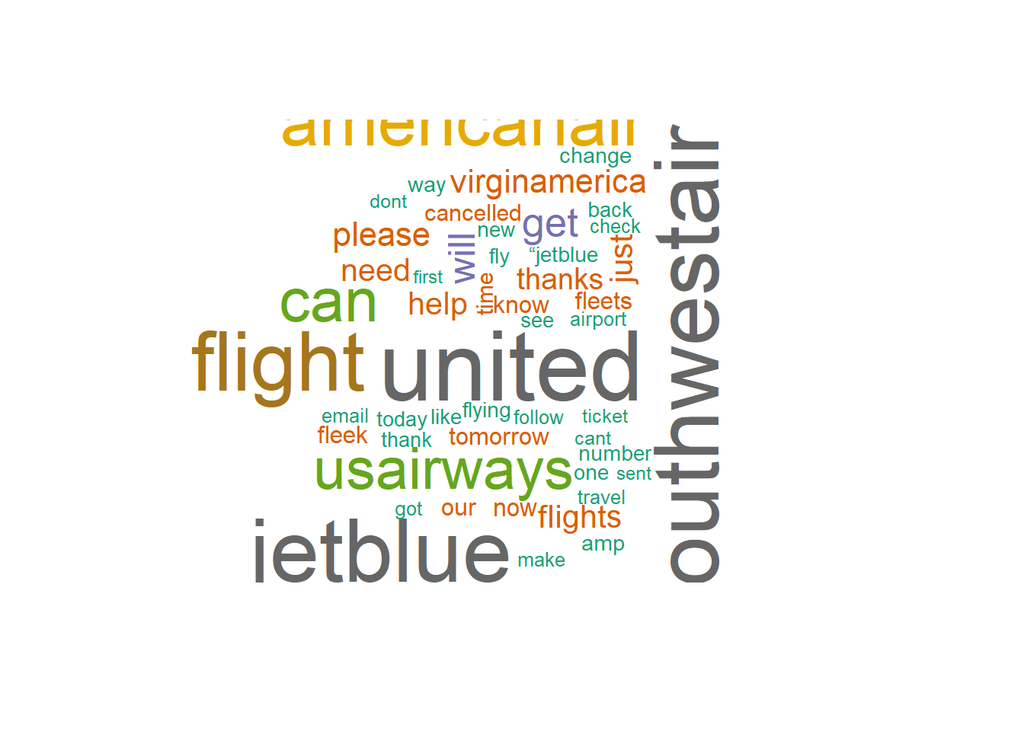

```r
wordcloud(neutral$text ,max.words=50, colors=brewer.pal(8, "Dark2"))
```

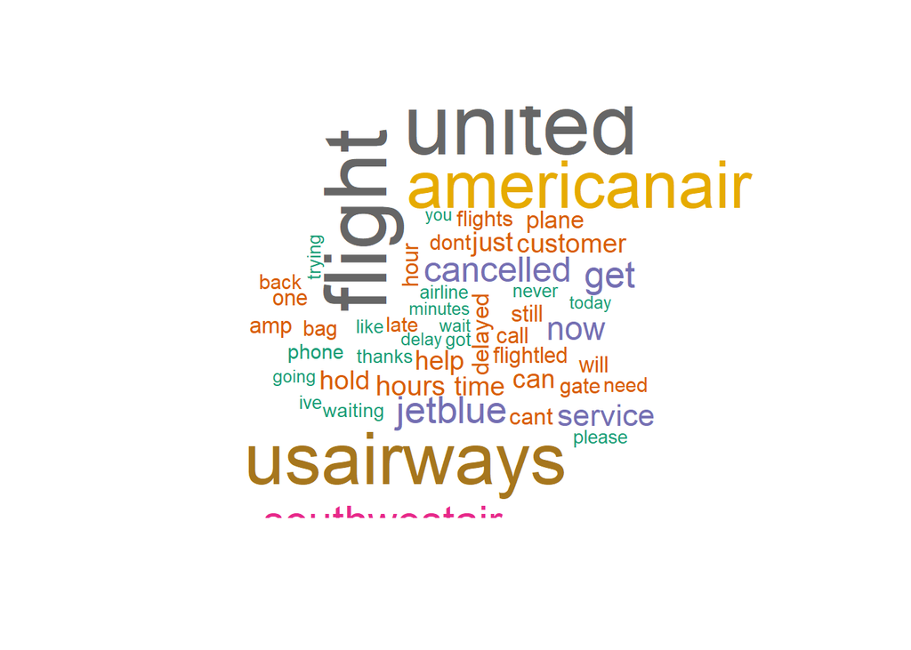

[output not shown]

```r
wordcloud(negative$text, max.words=50, colors=brewer.pal(8, "Dark2"))
```

- 위를 살펴보면, southwestair, americanair, united, flight등 감정 판단과 관련없는 항공사 이름/단어들이 자주 등장하는 것을 볼 수 있다.

  | sentiment | words |
  | --- | --- |
  | positive | thank, best, love, good, great, appreciate |
  | neutral | thanks please need cancelled help |
  | negative | delayed please late don’t never hold |

- 아까보다는 적게 등장하지만 감정 판단에 영항을 미칠 것으로 보이는 단어들은 위와 같음을 확인할 수 있다.
- positive와 negative 단어들은 비교가 되지만 neutral은 크게 감정 판단에 영향을 줄 것으로 보이는 단어들을 파악하기 힘들다. 분석에 있어서도 nuetral을 예측하는 것이 어려울 것 같다.